# 住宅ストックとフロー

岩田真一郎（神奈川大学経済学部）

2025-03-15作成，2026-05-01改訂

［PDF形式：505KB］

供給曲線が一定のまま，人口増加によって住宅需要が増える（需要曲線が右方シフトする）と，住宅価格は上昇します．それでは，価格はどの**程度**上昇するでしょうか？これは，価格上昇に対して，どれほど柔軟に生産者が供給量を増やせるかに依存します．需要と供給の図を用いた分析では，供給曲線の形状（傾き）に密接に関係します．

供給曲線の形状は時間とともに変化（シフト）します．[住宅価格と住宅政策](https://shinichiro-iwata.github.io/lecture-notes-urban-econ/housing-price-and-policy.html)では，このような時間の経過については考えませんでした[^1]．住宅について考えると，ある時点における供給量は一定です．これを**（住宅）ストック**とよびます．この場合，住宅需要が増加しても供給量を増やすことができないため，価格の上昇幅は大きくなります．しかし，一定の期間が経過すると，住宅メーカーや不動産デベロッパーは新たに土地や建築資材を確保し，市場に住宅を追加できるようになります．この一定期間における供給量の変化を **フロー**とよびます．したがって，時間の経過とともに供給量が増え，価格の上昇幅は小さくなります．

本稿の第1節では，住宅の住宅供給量が固定されているある時点（ストック）の住宅価格と，一定期間における住宅供給の増減（フロー）が反映された後の住宅価格を推察します．第2節では，住宅価格の変化と都市・住宅政策による住宅ストックの増加の現状を説明します．第3節では，今後課題となる人口減少に伴うストック調整について考察します．

# 1 住宅供給曲線

生産者は，生産要素（労働，土地，建築資材）を投入して住宅を建築します．ミクロ経済学では，時間の概念として短期と長期があります．生産要素の投入量を調整できる場合，その生産要素は可変的生産要素とよばれます．一方，一定期間は投入量を増減できない生産要素もあり，それを固定的生産要素といいます．固定的生産要素が存在する期間を短期，すべての生産要素の投入を調整できる期間を長期とよびます．

ただし，時間の概念をより細かく定義して，供給曲線の形状の違いを描写するテキストもあります．ここでは，そのような例にならい，時間の概念を3つ（第1.4節では4つ）の期間に分け，ストックとフローの概念を取り入れながら説明を進めます．

## 1.1 短期

生産要素はすべて固定的生産要素と仮定します．この場合，住宅供給量はある時点のストックに等しくなり，短期の間に変化しません．そのため，住宅の供給曲線は図1のSS<sub>0</sub>のように垂直に描かれ，傾きは絶壁のように急になります．右上がりの供給曲線とは異なり，住宅価格が変化しても供給量はH<sub>0</sub>のまま変わりません．

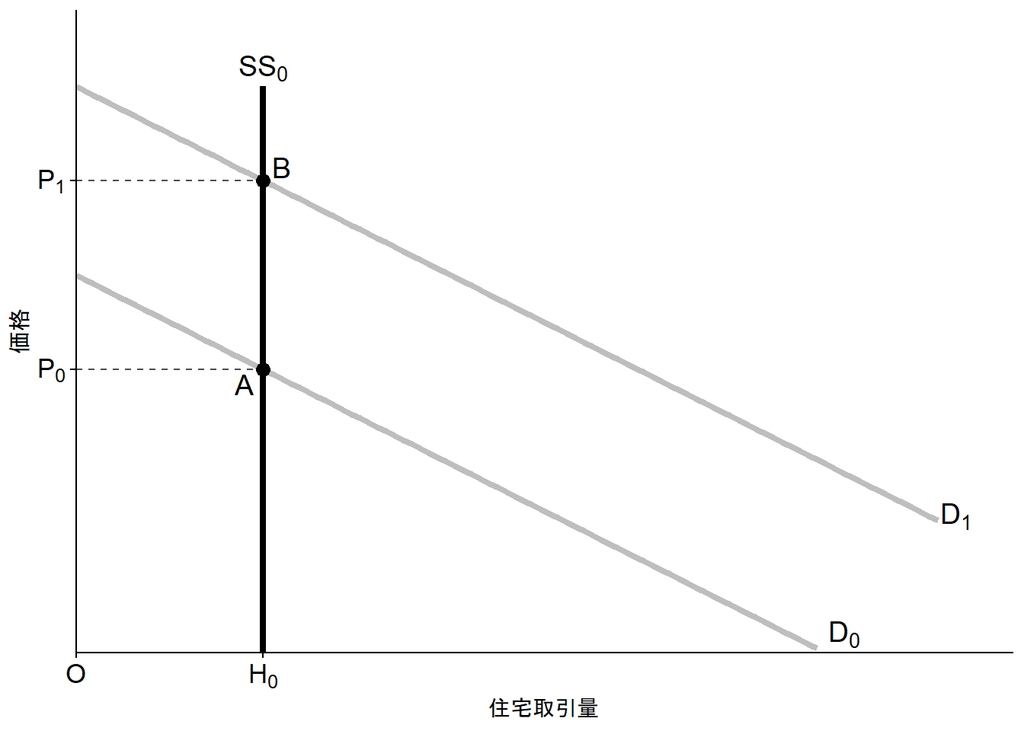

図1：短期の住宅供給曲線と均衡価格

当初の住宅需要曲線がD<sub>0</sub>の場合，均衡点はA点になり，均衡価格と均衡取引量の組み合わせはP<sub>0</sub>とH<sub>0</sub>になります．ここで，人口が増加し，需要曲線がD<sub>0</sub>からD<sub>1</sub>に右方シフトしたとしましょう．新しい均衡点はB点に移ります．供給曲線が垂直ですので，均衡取引量はH<sub>0</sub>のまま，均衡価格はP<sub>0</sub>からP<sub>1</sub>へと大きく上昇します[^2]．

## 1.2 中期

住宅市場にはどのような変化が及ぼされるでしょうか．それを描いたのが図2です．中期になると，供給曲線の傾きは緩やかになり，MSのような右上がりに曲線になります．この結果，新しい均衡点はC点に移動し，均衡取引量はH<sub>1</sub>に増加し，均衡価格はP<sub>2</sub>に低下します．

中期の時点での住宅ストックH<sub>1</sub>は既存ストックH<sub>0</sub>に新築フローΔH<sub>MS</sub>（H<sub>1</sub>とH<sub>0</sub>の差）を加えた値に等しくなります．

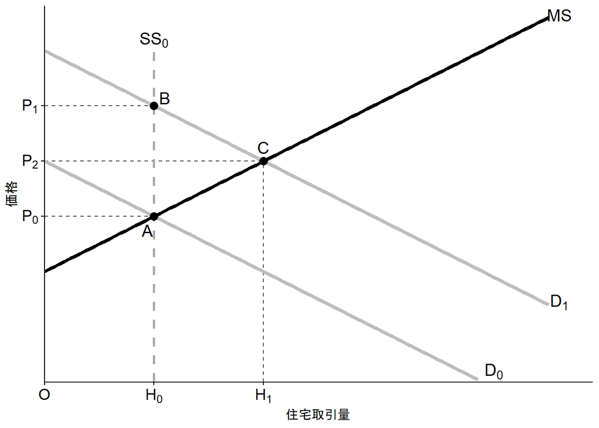

図2：中期の住宅供給曲線と均衡価格

当初の住宅価格P<sub>0</sub>から比較すると，短期に比べて中期の方が住宅の上昇幅が抑えられていることに気づきます．これは，短期に比べて中期の方が，価格の上昇に対して，供給量の増加が柔軟になったからです．

## 1.3 長期

すべての生産要素を変えられるような期間になると，既存の生産者の増産だけではなく，潜在的な生産者も，生産要素を揃え，市場への参入が可能になります．このような期間を長期とよびましょう．

生産者の新規供給は，供給曲線の傾きをますます緩やかにします．そして，極端な場合は，図3のLSのような水平な供給曲線が得られます．仮にこのLSが実現すると，新しい均衡点はE点に移動します．均衡取引量（長期の時点での住宅ストック）はH<sub>2</sub>に増加します．すなわち，中期から長期にかけてH<sub>2</sub>とH<sub>1</sub>の差のフローが加わります．その結果，均衡価格はP<sub>0</sub>に低下します．

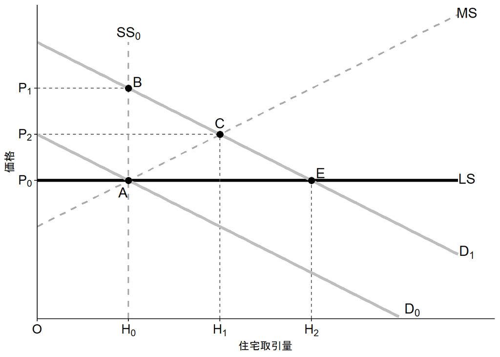

図3：長期の住宅供給曲線と均衡価格

興味深いことに，長期の均衡価格P<sub>0</sub>は当初の均衡価格と等しいことです．これは，当初の価格水準における住宅需要の増加を賄うだけ，短期から長期にかけてフロー（ΔH<sub>LS</sub>：H<sub>2</sub>とH<sub>0</sub>の差）が増加したためです．

以上から，住宅の均衡価格は，当初は大きく上昇しますが，時間が経つにつれて，低下してゆき，基の水準に落ち着きます．そして，長期のような期間を考えると，価格上昇を伴わずに，住宅供給量の増加が見込まれるのです．このことは，今までより多くの消費者が，基の価格水準で住宅を消費する機会に恵まれることを意味します．

## 1.4 住宅価格の推移

図4は，上で述べたことを，住宅ストックの違いのみで表現しています．A点が達成された時点を第0期，B点が達成された時点を第1期としましょう．第0期，第1期時点の住宅ストックはH<sub>0</sub>で表され，短期の供給曲線はこれまで通りSS<sub>0</sub>で表されます．次に，C点が達成された時点を第2期としましょう．第2期時点では，住宅ストックはH<sub>1</sub>に増加しています．この第2期においても，短期の間は生産要素の投入量は固定されるため，第2期時点の短期供給曲線はSS<sub>1</sub>で表現できます．同様に，E点が達成された時点を第3期とすると，第3期時点では，住宅ストックはH<sub>2</sub>に増加し，短期供給曲線はSS<sub>2</sub>で表現できます．

図4のように表すと，住宅ストックの変化に応じて，均衡価格がどのように推移するのかを表現できます．第0期から第1期の均衡価格は，需要曲線が右方シフトするのに対して，住宅ストックは変わらないため，P<sub>0</sub>からP<sub>1</sub>に大きく上昇します．しかし，第1期から第2期へ，第2期から第3期へ向かうと，住宅ストックが増加するため，均衡価格は新しい需要曲線D<sub>1</sub>に沿って，基の価格P<sub>0</sub>まで低下していきます．

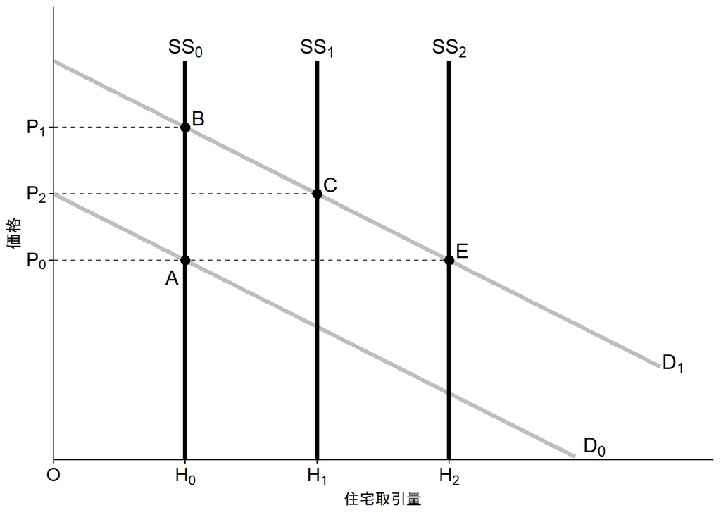

図4：均衡価格の推移

# 2 都市・住宅政策とストックの拡充

本稿執筆現在（2025年3月），東京都心部ではマンション価格が上昇基調にあります（外山・伊藤，2024）．この上昇は，これらの地点に対する旺盛な住宅需要に支えられていると予想されます．

問題は，地域地区制により，マンションの自由な建設が制限されていることです[^3]．このような規制が存在すると，住宅供給曲線はSS<sub>0</sub>から変化せず，その結果，価格がP<sub>1</sub>に高止まりし，先ほどみたような時間を通じた価格の低下は見られくなります．

しかし，現実にはこのような希少な場所で，不動産デベロッパーは競うように高層マンションを建設しています[^4]．これには，都市・住宅政策による規制緩和が大きな役割を果たしています．[市街地再開発事業](https://www.mlit.go.jp/jutakukentiku/house/seido/06sigaichisai.html)の施行区域に認定されると，高さや容積率の規制が緩和され，高層化が可能になります（野澤，2024）．不動産デベロッパーは自治体と協力したり，自治体の要請を受けたりしながら，こうした地域の用地を取得し，高層マンションを建設してきました[^5]．このような動きは，東京都心部だけではなく，各地の地方都市にも及んでいます（浅沼，2023）．

図5（a）は，2023年時点の東京都23区における共同住宅戸数（住宅土地統計調査）を示しており，23区の外縁部で相対的に戸数が大きいことがわかります．一方，図5（b）は，2003年から2023年の増加率を示しており，23区の中心部で増加率が高いことがうかがえます．東京都心部の市街地再開発事業における高層マンションの建設は，この増加率に寄与している可能性があります．

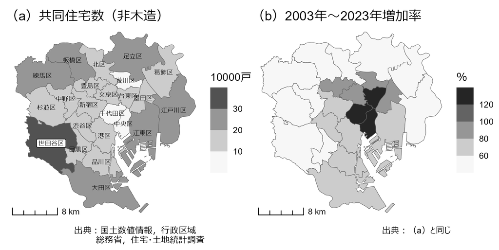

図5：東京都23区共同住宅数とその変化

現在の状況は，中期の状況を観察しているのかもしれません．すなわち，P<sub>0</sub>からP<sub>2</sub>への価格の上昇で，同時に，東京都心部のマンションストックは以前よりも増加しています．規制緩和がなければ，マンション価格はより高い水準だったかもしれません．今後も，不動産デベロッパーは採算がある（価格がP<sub>0</sub>より高い）限り，マンション開発を推し進めるでしょう．これによりストックの増加が進めば，マンション価格は基の水準P<sub>0</sub>に落ち着くことになります．このとき，マンション開発の動きは止まることになります．

# 3 人口減少とストック調整

一方で，神戸市のように（都心部において）高層マンションの建設を規制する動きも見られます（浅沼，2023）[^6]．神戸市の人口は2011年の154万人をピークに減少が続き，2023年には150万人を割れました．人口減少に伴う住宅需要の減少は，いずれ神戸都心部にも及ぶかもしれません．

住宅需要の減少は，これまで説明してきたメカニズムを逆方向に回転すればよいはずです．図6において，第0期の均衡が，短期の供給曲線SS<sub>2</sub>と需要曲線D<sub>1</sub>の交点，E点，で達成されていたとしましょう．住宅ストックはH<sub>2</sub>で，均衡価格はP<sub>0</sub>です．第1期に，人口が減少して，住宅需要曲線がD<sub>1</sub>からD<sub>0</sub>に左方シフトすると，均衡点はF点に移動し，均衡価格はP<sub>3</sub>に大きく低下します．これは，住宅ストックがH<sub>2</sub>のままだからです．

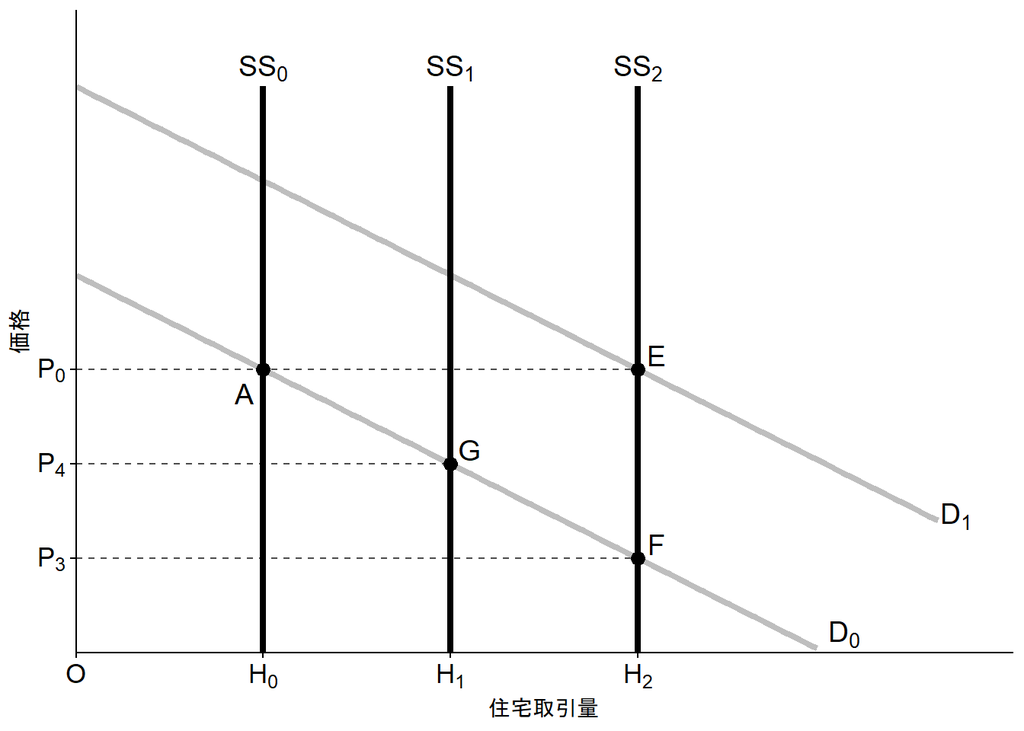

図6：建物の解体・取り壊しとストック調整

しかし，この低価格の下で採算が合わなくなると，建物の解体や取り壊しを行う生産者が現れ始めます．この結果，住宅ストックの減少が生じます．図6では，第2期になると，住宅ストックはH<sub>1</sub>まで減少し，均衡点はG点に移動します．均衡価格は，新しい需要曲線D<sub>0</sub>に沿って，P<sub>4</sub>まで上昇します．さらに，第3期には，住宅ストックはH<sub>0</sub>まで減少し，均衡点はA点に移動します．そして，均衡価格は基の水準P<sub>0</sub>まで上昇し，ストック調整が終了します．

現実の課題は，このような解体や取り壊しを通じたストック調整が本当に進むかがです（野澤，2024；森，2024）．住宅ストックがH<sub>2</sub>のまま減らないという極端な例を考えると，本来P<sub>0</sub>まで回復するはずの住宅価格がP<sub>3</sub>のまま低迷することになります．採算が合わないにもかかわらず住宅ストックが減らないことは，非効率的な資源配分（例えば，土地を他の用途に利用した方がよい）を引き起こすことを意味します．

住宅ストックを減らさないにもかかわらず，生産者が住宅価格P<sub>0</sub>からの低下を受け入れないという極端な場合はどうでしょう．このとき，住宅需要量はH<sub>0</sub>であるのに対し，住宅供給量（住宅ストック）はH<sub>2</sub>であるため，住宅の超過供給が生じます．その結果，この分の住宅は空き家になります．したがって，この場合も資源配分は非効率的になります．

# 4 テキストガイド

本稿は，価格上昇に対して，生産者が供給量をどれほど柔軟に変化させられるのかを，供給曲線の形状（傾き）を用いて考えました．

- スティーヴン・レヴィット，オースタン・グールズビー， チャド・サイヴァーソン（安田洋祐監訳・高遠裕子訳）（2017）[『レヴィット ミクロ経済学 基礎編』](https://str.toyokeizai.net/books/9784492314951/)東洋経済新報社．

の第2章では，人口増加に伴う住宅需要の増加が住宅価格に与える影響を二つの都市（ニューヨークとヒューストン）の供給曲線の形状（傾き）の違いから分析しています．

ミクロ経済学では，価格に対する供給量の反応度は供給の**価格[弾力性](https://ja.wikipedia.org/wiki/%E5%BC%BE%E5%8A%9B%E6%80%A7)**で考えます．供給の価格弾力性は，価格が1％変化したときに，供給量が何％変化するのかを測る指標であり，供給量の変化率を価格の変化率で割ることにより求まります．この式を変形すると，図3のA点のように複数の供給曲線が交わる箇所では，傾きが緩やかな供給曲線ほどその点における弾力性が大きくなることが知られています．供給曲線の傾きが最も急なのが短期の供給曲線SS<sub>0</sub>であり，供給の価格弾力性は0になります．これは，価格が変化しても，供給量がまったく変化しないからです．中期になると，供給曲線がMSのようにシフトし，傾きは緩やかになります．このとき，価格が変化すると，供給量も変化します．その結果，供給の価格弾力性は正の値を取ります．長期では，供給曲線がLSのようにシフトし，傾きは最も緩やかになります．そして，供給の価格弾力性は無限大になります．これは，価格がわずかにでも変化すると，供給量が極端に増減することを反映しています．

このように時間とともに供給の価格弾力性の大きさが変化する詳しい説明については，次のテキストの第5章を参照してください．

- 八田達夫（2008）[『ミクロ経済学I市場の失敗と政府の失敗への対策』](https://str.toyokeizai.net/books/9784492812983/)東洋経済新報社．

本稿は，住宅供給量のストックとフローの概念を説明しました．次の洋書テキストの第7章は，**ストック・フローモデル**をわかりやすく解説しています．

- Brueckner, Jan K.（2011）[“Lectures on Urban Economics”](https://mitpress.mit.edu/9780262016360/lectures-on-urban-economics/)，MIT Press．

# 参考文献

- 浅沼直樹（2023）[「高層ビル開発，地方に波及 2つの規制緩和で競争過熱」](https://www.nikkei.com/article/DGXZQOUE0459W0U3A400C2000000/)『日本経済新聞』2023年4月30日．↩︎
- 浅沼直樹・田中健斗（2024）[「都市人口の2割，工業系地域に 規制が緩くタワマン林立」](https://www.nikkei.com/article/DGXZQOUE191BV0Z10C24A7000000/)『日本経済新聞』2024年8月4日．↩︎
- 外山尚之・伊藤陽萌（2024）[「東京23区「億ション」常態化 4〜9月，1億円超続く」](https://www.nikkei.com/article/DGXZQOUC179CR0X11C24A0000000/)『日本経済新聞』2024年10月21日．↩︎
- 野澤千絵（2024）[『2030年ー2040年 日本の土地と住宅』](https://www.chuko.co.jp/laclef/2024/12/150828.html)中公新書ラクレ．↩︎
- 森知也（2024）[「第4話 100年後の都市と地域のすがた （後編）」](https://mori-column.notion.site/top)『都市を通して考える日本の未来』2024年4月15日（アクセス日：2025年3月15日）．↩︎

# R環境

**セッション情報**

- R version 4.4.3 (2025-02-28 ucrt)
  - RStudio 2024.12.1+563
  - rmarkdown_2.29

**使用したパッケージ**

- `tidyverse`

# リンク

[都市経済学講義ノート](https://shinichiro-iwata.github.io/lecture-notes-urban-econ/)

[Rによる地理空間データの可視化](https://shinichiro-iwata.github.io/geospatial-data-visualization/)

[Shinichiro Iwata](https://shinichiro-iwata.github.io/)

**アイコン**

Font Awesome 6.3.0

**生成AIの使用について**

ChatGPTのサービスを利用した後，内容を確認し，必要に応じて編集を行いました．

[^1]: [住宅価格と住宅政策](https://shinichiro-iwata.github.io/lecture-notes-urban-econ/housing-price-and-policy.html)の第5節（2）賃貸価格と住宅価格では時間の概念を取り入れましたが，住宅の取引単位は1単位に固定していました．
[^2]: 経済学では，供給曲線が垂直なときに生産者が得る収入を**経済（的）レント**とよびます．
[^3]: 地域地区制の住宅市場に与える影響は[住宅価格と住宅政策](https://shinichiro-iwata.github.io/lecture-notes-urban-econ/housing-price-and-policy.html)の第4節（1）土地利用規制を参照してください．
[^4]: その他，工場跡地に高層マンションが林立する傾向が見受けられます（浅沼・田中，2024）．
[^5]: 具体的には，既存の建物や土地の所有者に対して，その資産に見合った面積（権利床）を保証し，新たに建設されるマンションによって生まれる追加面積（保留床）を売却して事業費をまかなう仕組み（第1種市街地開発事業）です．
[^6]: 神戸市は山陽新幹線新神戸駅～JR三宮駅～JR神戸駅周辺の都心部を[「都心機能活性化地区」](https://www.city.kobe.lg.jp/a84931/shise/kekaku/jutakutoshikyoku/kobetoshin/tochiriyou-sesaku/toshinkino_yudo.html)と位置づけ，2020年7月1日より住宅用途に供する容積率の上限を400％に制限しています．